# Grupo 1: Palmeiras do JBRJ

### 🔴 Sugestão do professor

O último gráfico de dispersão apresentado repetia a informação já comunicada pelo gráfico anterior. Após constatar a correlação pelo coeficiente de Spearman, vocês poderiam ter explorado outras tendências além da reta, como a quadrática (azul) e a regressão local (loess, laranja).

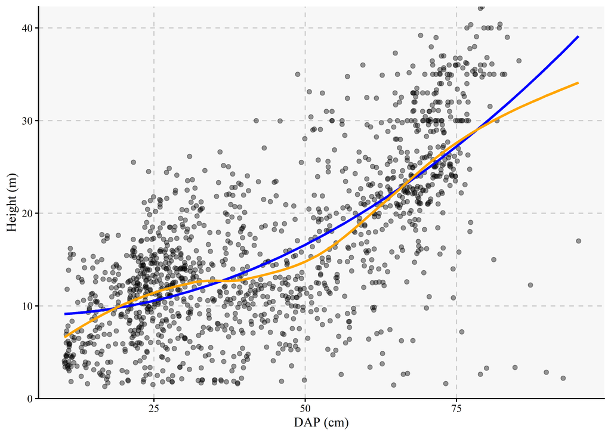

```r
# Gráfico de dispersão para palmeiras no arboreto
disp_lm<-
ggplot(palmeira, aes(x = dap, y = altura)) +
  geom_point(alpha = 0.4) +
  geom_smooth(method = "lm", formula = y ~ poly(x, 2), se = F, color = "blue") +
  geom_smooth(method = "loess", se = F, color = "orange") +
  scale_y_continuous(limits = c(0, NA), expand = c(0, 0)) +
  labs(x = "DAP (cm)", y = "Height (m)") +
  theme_classic() +
  theme(text = element_text(family = "serif"),
        panel.grid.major.y = element_line(linetype = "dashed", color = "gray80"),
        panel.grid.major.x = element_line(linetype = "dashed", color = "gray80"),
        panel.background = element_rect(fill = "grey97"))

# Visualização
disp_lm
```

## Pergunta 4: Há plantas com proporções incomuns de altura em relação ao DAP? Quais indivíduos apresentam valores extremos de relação altura/DAP, e esses indivíduos merecem atenção no monitoramento?

### Há plantas com proporções incomuns de altura em relação ao DAP?

#### Subset 10 gêneros mais frequentes

```r
# Identificar os 10 gêneros mais frequentes (excluindo NA)
subset_genero <- palmeira %>%
  filter(!is.na(genus)) %>%
  count(genus, sort = TRUE) %>%
  slice_head(n = 10) %>%
  pull(genus)

# Criar o subset apenas com esses gêneros
palmeira2 <- palmeira %>%
  filter(genus %in% subset_genero)
#Unique
unique(palmeira2$genus)
```

```
##  [1] "Elaeis"          "Roystonea"       "Euterpe"         "Syagrus"
##  [5] "Livistona"       "Sabal"           "Attalea"         "Archontophoenix"
##  [9] "Phoenix"         "Dypsis"
```

#### Detecting outliers

```r
# Creating a frequency table by gender
gen_palm <- palmeira2 %>%
  filter(!is.na(genus)) %>%
  count(genus, name = "Freq_obs") %>%
  arrange(desc(Freq_obs))

# Checking
head(gen_palm, 10)
```

```
##              genus Freq_obs
## 1        Roystonea      540
## 2        Livistona      146
## 3          Attalea      100
## 4          Syagrus       62
## 5          Phoenix       49
## 6          Euterpe       47
## 7           Elaeis       46
## 8  Archontophoenix       41
## 9           Dypsis       33
## 10           Sabal       26
```

```r
# Construindo um boxplot da relação altura x diametro
tiff("Boxplot_folhas_versaofinal.tiff", width = 200, height = 120, res = 400, units = "mm")

ggplot(palmeira2, aes(x = genus, y = rel_hd)) + theme_bw(
  base_size = 11) +
  geom_boxplot(width = .5,outlier.colour = NA) +
  geom_jitter(
    width = .07,
    alpha = .2,
    size = 1.5,
    color = "#A9A9A9"
  ) +
  labs(
    x = "Gêneros", size = 4,
    y = "Esbeltez"
  )

dev.off()
```

### 🔴 Sugestão do professor

O boxplot não foi exibido porque o código para salvar a figura está sendo executado diretamente no *chunk*. Além disso, devido à extensão dos nomes dos gêneros, seria conveniente inverter as coordenadas do gráfico. A correção seria:

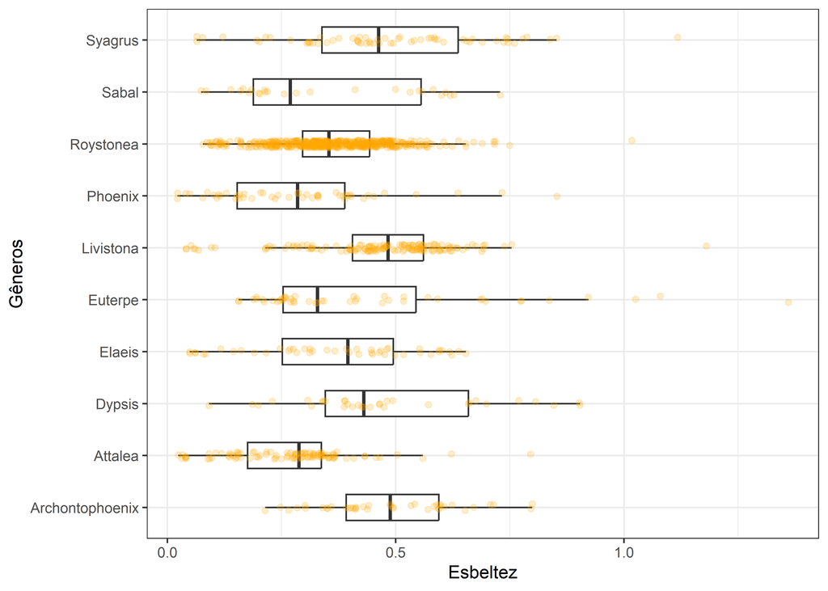

```r
# Construindo um boxplot da relação altura x diametro
ggplot(palmeira2, aes(x = genus, y = rel_hd)) + theme_bw(
  base_size = 11) +
  geom_boxplot(width = .5,outlier.colour = NA) +
  geom_jitter(
    width = .07,
    alpha = .2,
    size = 1.5,
    color = "orange"
  ) +
  labs(
    x = "Gêneros", size = 4,
    y = "Esbeltez"
  ) +
  coord_flip()
```

### Quais indivíduos apresentam valores extremos de relação altura/DAP?, e esses indivíduos merecem atenção no monitoramento?

#### Quem são os outliers?

```r
#Para identificar quem são os outliers
#Limite inferior
Q1 <- quantile(palmeira2$rel_hd, 0.25, na.rm = TRUE)
#Limite superior
Q3 <- quantile(palmeira2$rel_hd, 0.75, na.rm = TRUE)

IQR <- Q3 - Q1

lim_inf <- Q1 - 1.5 * IQR
lim_sup <- Q3 + 1.5 * IQR

outliers <- palmeira2 %>%
  filter(rel_hd < lim_inf | rel_hd > lim_sup)

outliers
```

```
##    sec_cant tombo    family           genus          species
## 1        3A   443 Arecaceae         Euterpe       precatoria
## 2        3A   488 Arecaceae         Euterpe       precatoria
## 3        3A   518 Arecaceae         Euterpe         oleracea
## 4        4A   774 Arecaceae          Dypsis madagascariensis
## 5        4A   783 Arecaceae          Dypsis madagascariensis
## 6        4C   959 Arecaceae         Euterpe   longibracteata
## 7        4G  1111 Arecaceae         Euterpe         oleracea
## 8        6A  1446 Arecaceae          Dypsis             <NA>
## 9        9A  2143 Arecaceae         Attalea             <NA>
## 10       9C  2229 Arecaceae       Roystonea         oleracea
## 11      10A  2428 Arecaceae         Syagrus    romanzoffiana
## 12      11F  2769 Arecaceae Archontophoenix       alexandrae
## 13      11F  2771 Arecaceae       Livistona        chinensis
## 14      15C  3185 Arecaceae         Phoenix             <NA>
```

[output cut: 57 more lines]

```r
#Quantos são?
nrow(outliers)
```

```
## [1] 23
```

```r
# Ordenados mais extremos para o menos extremos
outliers %>%
  arrange(desc(rel_hd))
```

```
##    sec_cant tombo    family           genus          species
## 1       20D  4185 Arecaceae         Euterpe         oleracea
## 2       11F  2771 Arecaceae       Livistona        chinensis
## 3       16A  3385 Arecaceae         Syagrus         oleracea
## 4        4G  1111 Arecaceae         Euterpe         oleracea
## 5        3A   488 Arecaceae         Euterpe       precatoria
## 6        9C  2229 Arecaceae       Roystonea         oleracea
## 7        3A   443 Arecaceae         Euterpe       precatoria
## 8        4A   783 Arecaceae          Dypsis madagascariensis
## 9        4A   774 Arecaceae          Dypsis madagascariensis
## 10      15C  3185 Arecaceae         Phoenix             <NA>
## 11      16A  3378 Arecaceae         Syagrus         oleracea
## 12       6A  1446 Arecaceae          Dypsis             <NA>
## 13      22B  4609 Arecaceae         Syagrus    romanzoffiana
## 14       4C   959 Arecaceae         Euterpe   longibracteata
```

[output cut: 57 more lines]

```r
#Quem são os outliers dentro do mesmo gênero?

outliers_genero <- palmeira2 %>%
  group_by(genus) %>%
  mutate(
    Q1 = quantile(rel_hd, 0.25, na.rm = TRUE),
    Q3 = quantile(rel_hd, 0.75, na.rm = TRUE),
    IQR = Q3 - Q1,
    lim_inf = Q1 - 1.5 * IQR,
    lim_sup = Q3 + 1.5 * IQR
  ) %>%
  filter(rel_hd < lim_inf | rel_hd > lim_sup)
```

#### Ordenando pela Esbeltez dentro de cada gênero

```r
#Ordenando a esbeltex
outliers_genero %>%
  arrange(genus, desc(rel_hd)) %>%
  select(tombo, family, genus, species, altura, dap, rel_hd)
```

```
## # A tibble: 23 × 7
## # Groups:   genus [6]
##    tombo family    genus     species    altura   dap rel_hd
##    <int> <chr>     <chr>     <chr>       <dbl> <dbl>  <dbl>
##  1  2143 Arecaceae Attalea   <NA>        20.7   26.0 0.795
##  2  5038 Arecaceae Attalea   speciosa    18.5   29.8 0.622
##  3  4185 Arecaceae Euterpe   oleracea    15.2   11.1 1.36
##  4  1111 Arecaceae Euterpe   oleracea    17.7   16.4 1.08
##  5   488 Arecaceae Euterpe   precatoria  15.3   15.0 1.03
##  6  2771 Arecaceae Livistona chinensis   25.5   21.6 1.18
##  7  6267 Arecaceae Livistona saribus      4.23  40.5 0.105
##  8  9158 Arecaceae Livistona chinensis    1.99  20.7 0.0962
##  9  9083 Arecaceae Livistona chinensis    1.8   26.4 0.0681
## 10  9084 Arecaceae Livistona chinensis    1.5   24.8 0.0604
## # ℹ 13 more rows
```

#### Para visualização dos outliers

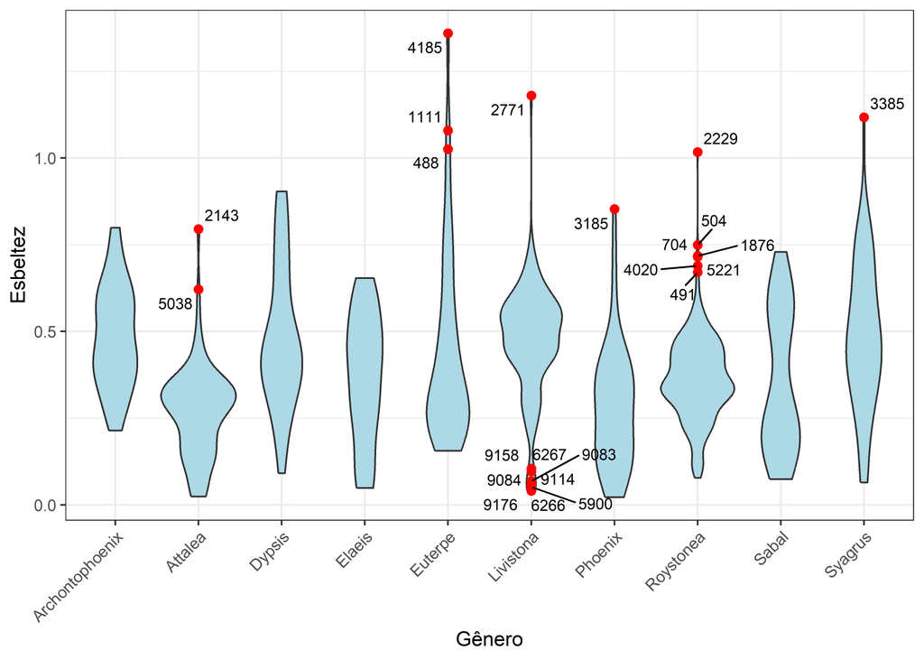

```r
#Gráfico de pontos
#install.packages("ggrepel")
library(ggrepel)

ggplot(palmeira2,
       aes(x = genus, y = rel_hd)) +
  geom_violin(fill = "lightblue") +


  geom_point(data = outliers_genero,
             size = 2,
             colour = "red") +

  geom_text_repel(
    data = outliers_genero,
    aes(label = tombo),
    size = 3,
    max.overlaps = Inf
  ) +

  theme_bw() +
  theme(
    axis.text.x = element_text(angle = 45,
                               hjust = 1)
  ) +
  labs(
    x = "Gênero",
    y = "Esbeltez"
  )
```

```r
str(palmeira2)
```

```
## 'data.frame':    1090 obs. of  17 variables:
##  $ sec_cant    : chr  "1A" "1A" "1A" "1A" ...
##  $ tombo       : int  5 14 20 32 43 44 45 46 48 49 ...
##  $ family      : chr  "Arecaceae" "Arecaceae" "Arecaceae" "Arecaceae" ...
##  $ genus       : chr  "Elaeis" "Elaeis" "Elaeis" "Roystonea" ...
##  $ species     : chr  "guineensis" "guineensis" "guineensis" "oleracea" ...
##  $ name        : chr  "Elaeis guineensis" "Elaeis guineensis" "Elaeis guineensis" "Roystonea oleracea" ...
##  $ habito_pad  : chr  "Arborescent" "Arborescent" "Arborescent" "Arborescent" ...
##  $ altura      : num  13.7 19.6 23.3 30.4 13.4 ...
##  $ dap         : num  32.8 37.9 35.7 50.9 55.3 ...
##  $ densidade   : num  0.54 0.54 0.54 0.52 0.52 0.52 0.52 0.52 0.52 0.52 ...
##  $ n_caule     : int  1 1 1 1 1 1 1 1 1 1 ...
##  $ multicaule  : int  0 0 0 0 0 0 0 0 0 0 ...
##  $ multicaule_l: chr  "No" "No" "No" "No" ...
##  $ rel_hd      : num  0.419 0.517 0.654 0.597 0.242 ...
##  $ area_basal  : num  0.0844 0.1127 0.1 0.2037 0.2398 ...
##  $ classe_alt  : Factor w/ 10 levels "(1.26,5.4]","(5.4,9.5]",..: 4 5 6 8 3 6 3 6 7 6 ...
##  $ classe_dap  : Factor w/ 10 levels "(10.1,18.7]",..: 3 4 3 5 6 6 5 6 7 7 ...
```

### Os indivíduos que apresentam valores extremos de relação altura/DAP merecem atenção no monitoramento?

#### Criação de Modelo esperada x observado

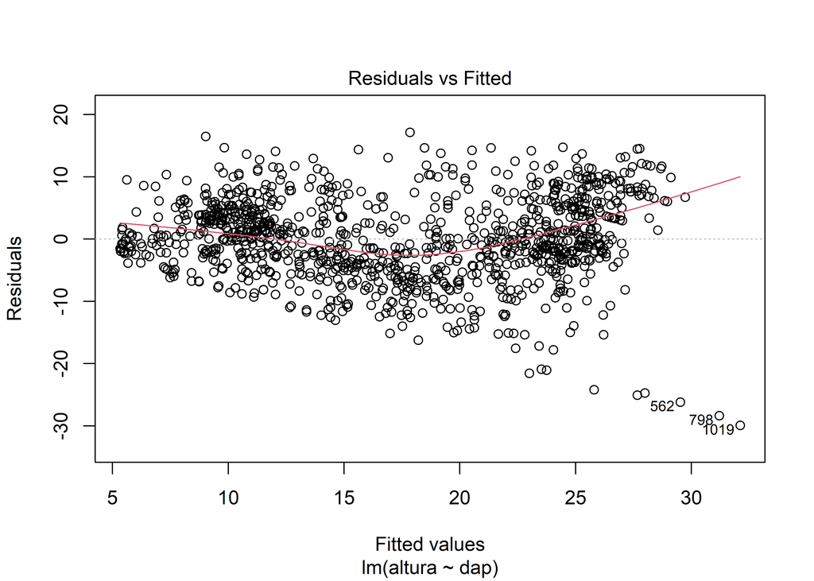

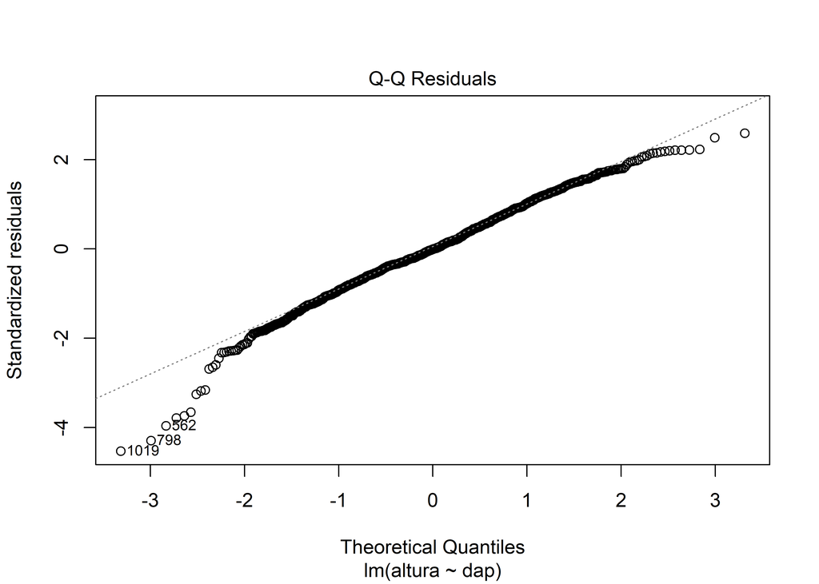

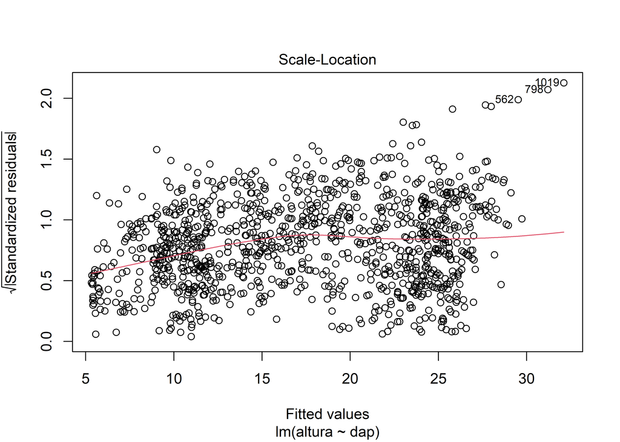

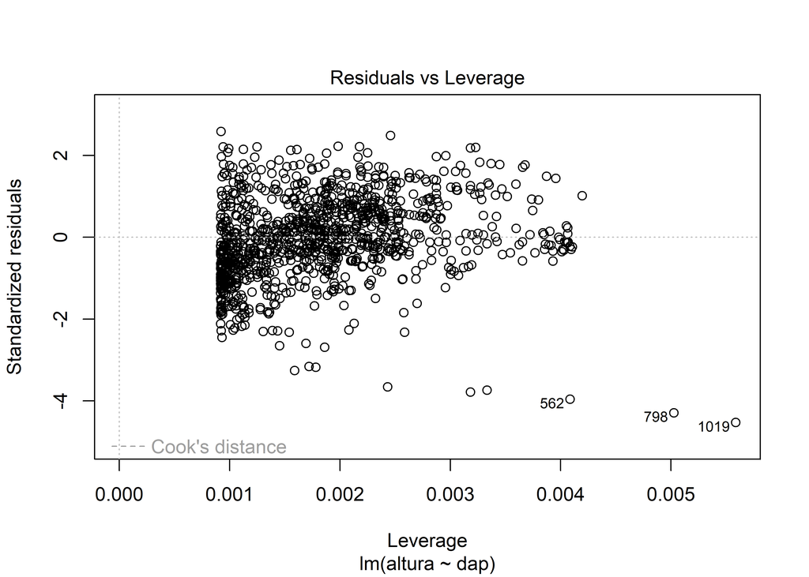

```r
#Modelo para ver a esbeltez esperada x observado
model1 <- lm(altura ~ dap, data = palmeira2)

plot(model1)
```

```r
summary(model1)
```

```
##
## Call:
## lm(formula = altura ~ dap, data = palmeira2)
##
## Residuals:
##      Min       1Q   Median       3Q      Max
## -29.9131  -3.8942  -0.0425   4.5952  17.1505
##
## Coefficients:
##             Estimate Std. Error t value Pr(>|t|)
## (Intercept)  1.99607    0.51736   3.858 0.000121 ***
## dap          0.32513    0.01003  32.400  < 2e-16 ***
## ---
## Signif. codes:  0 '***' 0.001 '**' 0.01 '*' 0.05 '.' 0.1 ' ' 1
##
## Residual standard error: 6.624 on 1088 degrees of freedom
## Multiple R-squared:  0.4911, Adjusted R-squared:  0.4906
## F-statistic:  1050 on 1 and 1088 DF,  p-value: < 2.2e-16
```

```r
#Residuos
palmeira2$altura_esperada <- predict(model1)

palmeira2$residuo <- residuals(model1)

palmeira2$residuo_pad <- rstandard(model1)
```

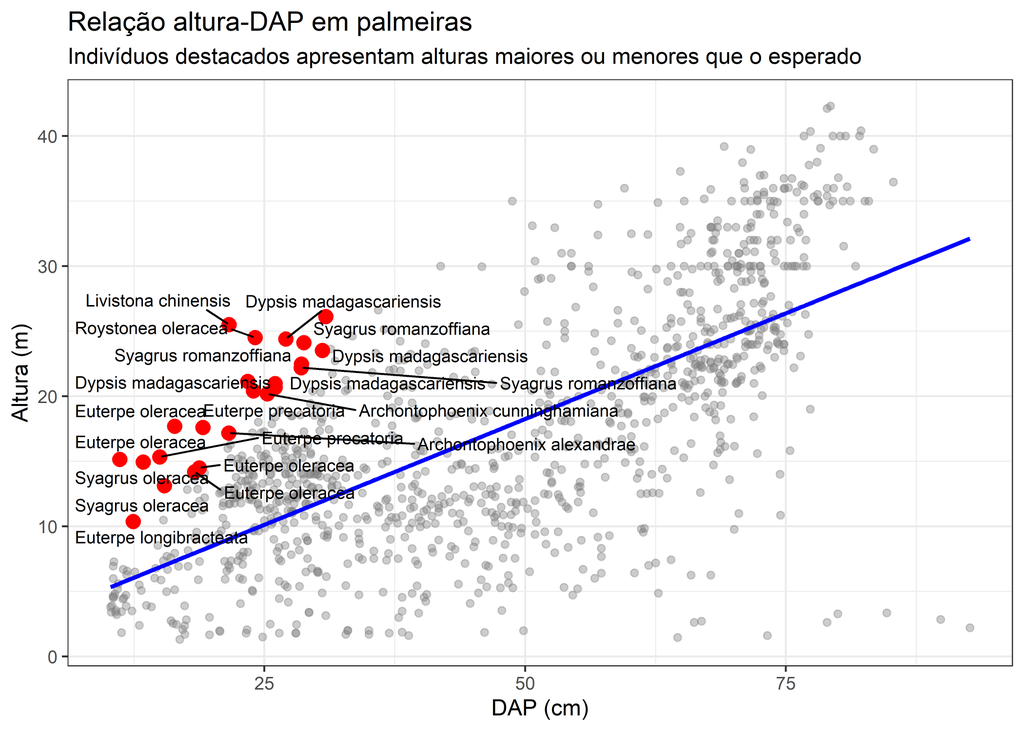

```r
#Visualização os outliers
ggplot(palmeira2,
       aes(x = dap, y = altura)) +

  geom_point(alpha = 0.4, color = "grey50") +

  geom_line(aes(y = altura_esperada),
            color = "blue",
            linewidth = 1) +

  geom_point(data = outliers,
             color = "red",
             size = 3) +

  geom_text_repel(
    data = outliers,
    aes(label = name),
    size = 3,
    max.overlaps = Inf
  ) +

  theme_bw() +
  labs(
    x = "DAP (cm)",
    y = "Altura (m)",
    title = "Relação altura-DAP em palmeiras",
    subtitle = "Indivíduos destacados apresentam alturas maiores ou menores que o esperado"
  )
```

### 🔴 Sugestão do professor

Lembro que, pelas boas práticas de programação, o ideal é carregar todos os pacotes utilizados no início do script.

A ideia de identificar os indivíduos extremos no gráfico de dispersão foi muito boa. No entanto, não vejo necessidade de incluir uma linha de tendência no gráfico, muito menos de gerar um modelo que, como já verificamos, não atende aos pressupostos necessários para esse tipo de ajuste.

## Pergunta 5: Os gêneros mais abundantes são também os dominantes? Avaliem quais concentram os maiores valores de altura e área basal.

```r
# Avaliem quais concentram os maiores valores de altura e área basal.
altbasal_genero <- palmeira %>%
  filter(!is.na(genus)) %>%
  group_by(genus) %>%
  summarise(
    n = n(),
    altura_media = mean(altura, na.rm = TRUE),
    altura_max = max(altura, na.rm = TRUE),
    area_basal_total = sum(area_basal, na.rm = TRUE),
    area_basal_media = mean(area_basal, na.rm = TRUE)
  ) %>%
  arrange(desc(area_basal_total))

altbasal_genero
```

```
## # A tibble: 57 × 6
##    genus             n altura_media altura_max area_basal_total area_basal_media
##    <chr>         <int>        <dbl>      <dbl>            <dbl>            <dbl>
##  1 Roystonea       540        23.3        42.3           175.             0.323
##  2 Attalea         100        11.7        21.0            18.6            0.186
##  3 Livistona       146        12.6        25.5             9.12           0.0625
##  4 Elaeis           46        14.7        24.0             6.20           0.135
##  5 Euterpe          47        11.6        17.7             5.06           0.108
##  6 Phoenix          49         6.10       20.4             3.73           0.0762
##  7 Mauritia         16        17.9        27.0             3.15           0.197
##  8 Syagrus          62        11.7        26.6             3.15           0.0508
##  9 Archontophoe…    41        13.8        22.8             2.87           0.0700
## 10 Sabal            26         9.40       14.3             2.26           0.0868
## # ℹ 47 more rows
```

```r
palmeira %>%
  filter(!is.na(genus)) %>%
  group_by(genus) %>%
  reframe(freq=n(), dom = sum(area_basal))%>%
  arrange(desc(freq))
```

```
## # A tibble: 57 × 3
##    genus            freq    dom
##    <chr>           <int>  <dbl>
##  1 Roystonea         540 175.
##  2 Livistona         146   9.12
##  3 Attalea           100  18.6
##  4 Syagrus            62   3.15
##  5 Phoenix            49   3.73
##  6 Euterpe            47   5.06
##  7 Elaeis             46   6.20
##  8 Archontophoenix    41   2.87
##  9 Dypsis             33   2.02
## 10 Sabal              26   2.26
## # ℹ 47 more rows
```

```r
palmeira %>%
      filter(!is.na(genus)) %>%
 group_by(genus) %>%
  summarise(
    freq = n(),
    dom = sum(area_basal, na.rm = TRUE)
  ) %>%
  arrange(desc(dom))
```

```
## # A tibble: 57 × 3
##    genus            freq    dom
##    <chr>           <int>  <dbl>
##  1 Roystonea         540 175.
##  2 Attalea           100  18.6
##  3 Livistona         146   9.12
##  4 Elaeis             46   6.20
##  5 Euterpe            47   5.06
##  6 Phoenix            49   3.73
##  7 Mauritia           16   3.15
##  8 Syagrus            62   3.15
##  9 Archontophoenix    41   2.87
## 10 Sabal              26   2.26
## # ℹ 47 more rows
```

```r
# Para avaliar a relação entre abundância e dominância
cor.test(
  altbasal_genero$n,
  altbasal_genero$area_basal_total,
  method = "spearman"
)
```

```
##
##  Spearman's rank correlation rho
##
## data:  altbasal_genero$n and altbasal_genero$area_basal_total
## S = 6186.4, p-value = 8.857e-14
## alternative hypothesis: true rho is not equal to 0
## sample estimates:
##       rho
## 0.7995058
```

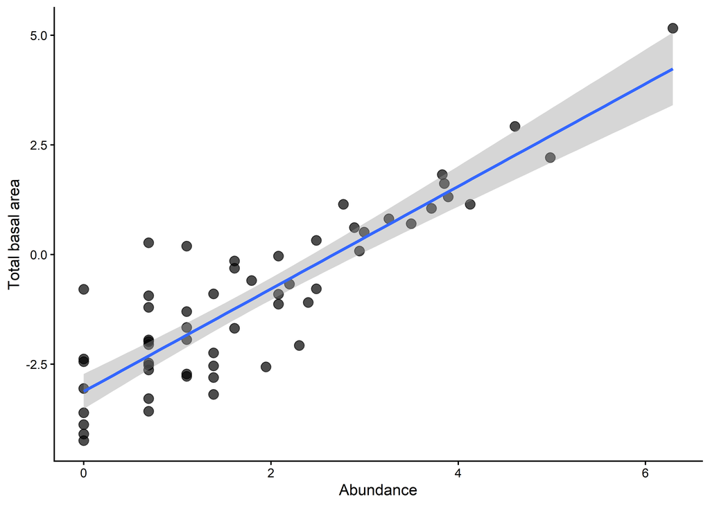

```r
# Gráfico de dispersão entre a abundância dos gêneros e sua área basal total.


ggplot(altbasal_genero,
       aes(x = log(n),
           y = log(area_basal_total))) +

  geom_point(size = 3, alpha = 0.7) +

  geom_smooth(method = "lm", se = TRUE) +

  labs(
    x = "Abundance",
    y = "Total basal area"
  ) +

  theme_classic()
```

### 🔴 Sugestão do professor

Uma sugestão para aprimorar a visualização seria identificar os gêneros no gráfico. Além disso, os títulos dos eixos deveriam ser corrigidos para log(abundância) e log(área_basal), de modo a refletir as transformações realizadas na escala das variáveis. Vejam:

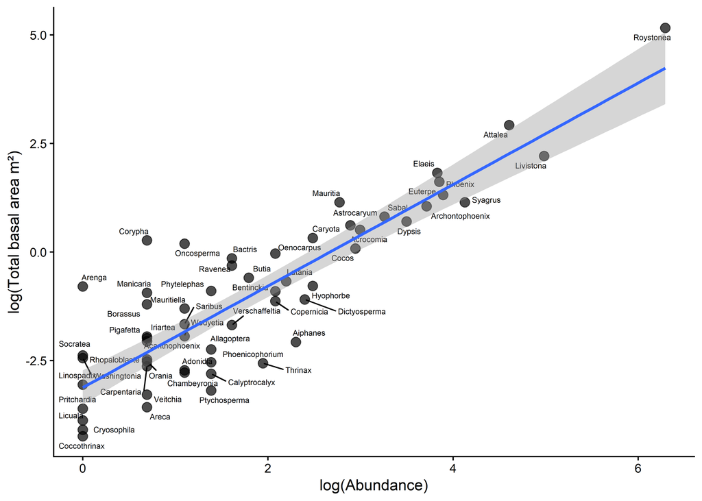

```r
# Gráfico de dispersão entre a abundância dos gêneros e sua área basal total.
ggplot(altbasal_genero, aes(x = log(n), y = log(area_basal_total))) +
  geom_point(size = 3, alpha = 0.7) +
  geom_text_repel(aes(label = genus), size = 2, max.overlaps = Inf) +
  geom_smooth(method = "lm", se = TRUE) +
  labs(x = "log(Abundance)", y = "log(Total basal area m²)") +
  theme_classic()
```

Acho que, para discutir essa questão no artigo, podemos utilizar outro tipo de gráfico: o *bump chart*. Sei que não abordamos esse tipo de visualização em aula, ele não me ocorreu naquele momento, apenas depois. Mas vejam abaixo como o gráfico fica mais informativo:

```r
# Rankeando área basal e abundância
rank_genero <- altbasal_genero %>%
  filter(n >= 3) %>%
  mutate(rank_abundancia = rank(-n, ties.method = "first"), rank_area_basal = rank(-area_basal_total, ties.method = "first"))
```

```r
# Convertendo a tabela para o formato longo
rank_long <- rank_genero %>%
  select(genus, rank_abundancia, rank_area_basal) %>%
  pivot_longer(cols = c(rank_abundancia, rank_area_basal), names_to = "variavel", values_to = "ranking") %>%
  mutate(variavel = recode(variavel, rank_abundancia = "Abundance", rank_area_basal = "Total basal area"),
    variavel = factor(variavel, levels = c("Abundance", "Total basal area")))
```

```r
# Gerando paleta de cores
generos <- sort(unique(rank_long$genus))

cores_genus <- colorRampPalette(RColorBrewer::brewer.pal(8, "Dark2"))(length(generos))

names(cores_genus) <- generos
```

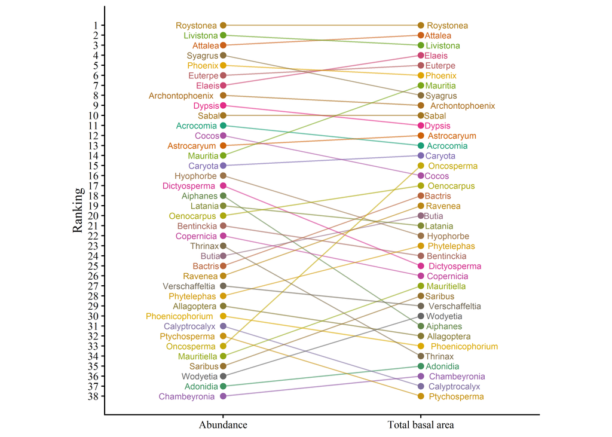

```r
# Visualizando os resultados
ggplot(rank_long, aes(x = variavel, y = ranking, group = genus, color = genus)) +
  geom_line(alpha = 0.6) +
  geom_point(size = 2) +
  geom_text(data = rank_long %>% filter(variavel == "Abundance"), aes(label = genus), hjust = 1.15, size = 2.5) +
  geom_text(data = rank_long %>% filter(variavel == "Total basal area"), aes(label = genus), hjust = -0.15, size = 2.5) +
  scale_y_reverse(breaks = seq(1, max(rank_long$ranking), by = 1)) +
  scale_color_manual(values = cores_genus) +
  coord_cartesian(clip = "off") +
  labs(x = NULL, y = "Ranking") +
  theme_classic() +
  theme(text = element_text(family = "serif"),
        legend.position = "none",
        plot.margin = margin(5.5, 60, 5.5, 60))
```

## Pergunta 6: Avaliem a altura dominante em canteiros com mais de 10 plantas.

```r
# Database link
raw_url <- "https://raw.githubusercontent.com/jmalonso55/Applied-Statistics-for-a-Tropical-Arboretum/refs/heads/main/data/processed_data.csv"
```

```r
# Loading data
data_trab <- read.csv(raw_url, sep = ",")
```

### Seleção dos canteiros com mais de 10 indivíduos

```r
#Seleção canteiros com + de 10 indivíduos
canteiros_validos <- palmeira %>%
  group_by(sec_cant) %>%
  filter(n() > 10)

unique(canteiros_validos$sec_cant)
```

```
##  [1] "1A"  "1B"  "2A"  "2B"  "3A"  "3B"  "3C"  "3D"  "4A"  "4B"  "4C"  "4D"
## [13] "4E"  "4F"  "4G"  "5C"  "6A"  "6C"  "6D"  "7F"  "8A"  "8B"  "8D"  "9C"
## [25] "10A" "11F" "13B" "19A" "20A" "20B" "20D" "25A" "26A" "30G" "31B" "11H"
## [37] "38B" "34A" "1F"  "26F" "41B"
```

```r
#Selecionar a planta mais alta dos canteiros para saber a altura dominante
altura_dom <- canteiros_validos %>%
  group_by(sec_cant) %>%
  slice_max(altura, n = 1) %>%
  summarise(
    altura_dominante = mean(altura),
    n_ind = first(n())
  )
```

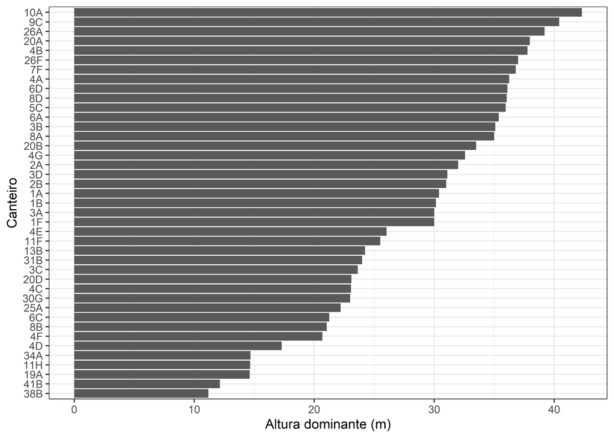

```r
#Visualização
#plot de plantas dominantes por canteiro
ggplot(altura_dom,
       aes(x = reorder(sec_cant, altura_dominante),
           y = altura_dominante)) +
  geom_col() +
  coord_flip() +
  theme_bw() +
  labs(
    x = "Canteiro",
    y = "Altura dominante (m)"
  )
```

### 🔴 Sugestão do professor

Faltou um pouco mais de cuidado na integração dos códigos produzidos pelos dois subgrupos durante o trabalho de sexta-feira. O código apresentado recarrega a base de dados de modo desnecessário, o que poderia ser evitado com uma revisão mais atenta da estrutura do script.

## Pergunta7: Seria possível agrupar canteiros ou gêneros de alguma forma?

### Agrupamento por estrutura

```r
#Agrupar os canteiros por estrutura
estrutura <- canteiros_validos %>%
  group_by(sec_cant) %>%
  summarise(
    n = n(),
    altura_media = mean(altura),
    altura_max = max(altura),
    dap_medio = mean(dap),
    area_basal_total = sum(area_basal),
    esbeltez_media = mean(rel_hd)
  )
```

```r
# Agrupando canteiros por estrutura

estrutura$sec_cant <- as.factor(estrutura$sec_cant)
estrutura$n <- as.factor(estrutura$n)

estrutura <- canteiros_validos %>%
  group_by(sec_cant) %>%
  summarise(
    n_ind = n(),
    altura_media = mean(altura, na.rm = TRUE),
    altura_max = max(altura, na.rm = TRUE),
    dap_medio = mean(dap, na.rm = TRUE),
    area_basal_total = sum(area_basal, na.rm = TRUE)
  )

view(estrutura)
```

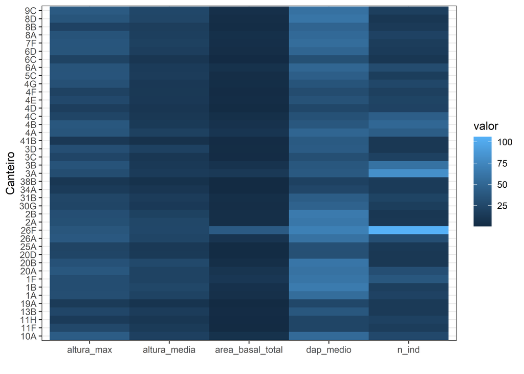

```r
#Heatmap

library(tidyr)

estrutura_long <- estrutura %>%
  pivot_longer(
    cols = -sec_cant,
    names_to = "variavel",
    values_to = "valor"
  )

ggplot(estrutura_long,
       aes(x = variavel,
           y = sec_cant,
           fill = valor)) +
  geom_tile() +
  theme_bw() +
  labs(x = "",
       y = "Canteiro")
```

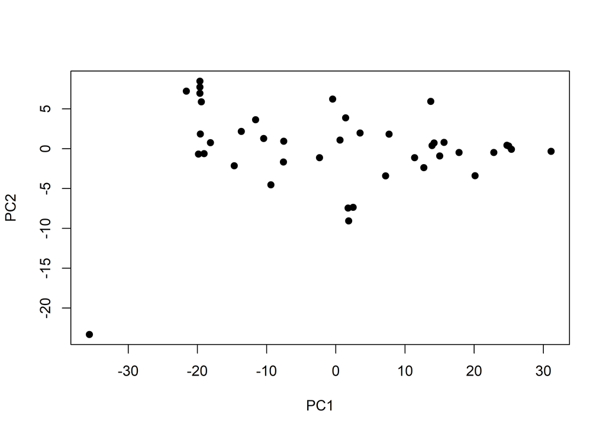

```r
# pca
pca <- prcomp(estrutura[c(3:6)])

plot(pca$x[,1],
     pca$x[,2],
     pch = 19,
     xlab = "PC1",
     ylab = "PC2")
```

```r
# text(pca$x[,1],
#      pca$x[,2],
#      labels = estrutura$sec_cant,
#      pos = 3)
```

## Para Arecaceae

### Façam um treemap com genero e espécie.

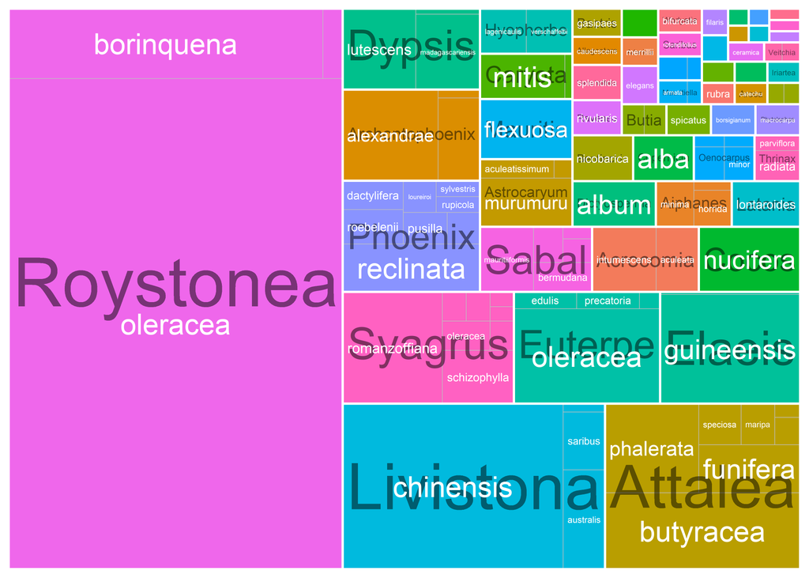

```r
# Dados para o treemap
tree_palmeira <- palmeira %>%
  filter(!is.na(genus),
         !is.na(species)) %>%
  group_by(genus, species) %>%
  summarise(freq = n()) %>%
  ungroup()

# Treemap
ggplot(tree_palmeira,
       aes(area = freq, fill = genus, label = species, subgroup = genus)) +
  geom_treemap() +
  geom_treemap_subgroup_border(color = "white", size = 2) +
  geom_treemap_subgroup_text(place = "centre", grow = TRUE, alpha = 0.5,color = "black") +
  geom_treemap_text(colour = "white", place = "centre", reflow = TRUE) +
  theme(legend.position = "none")
```

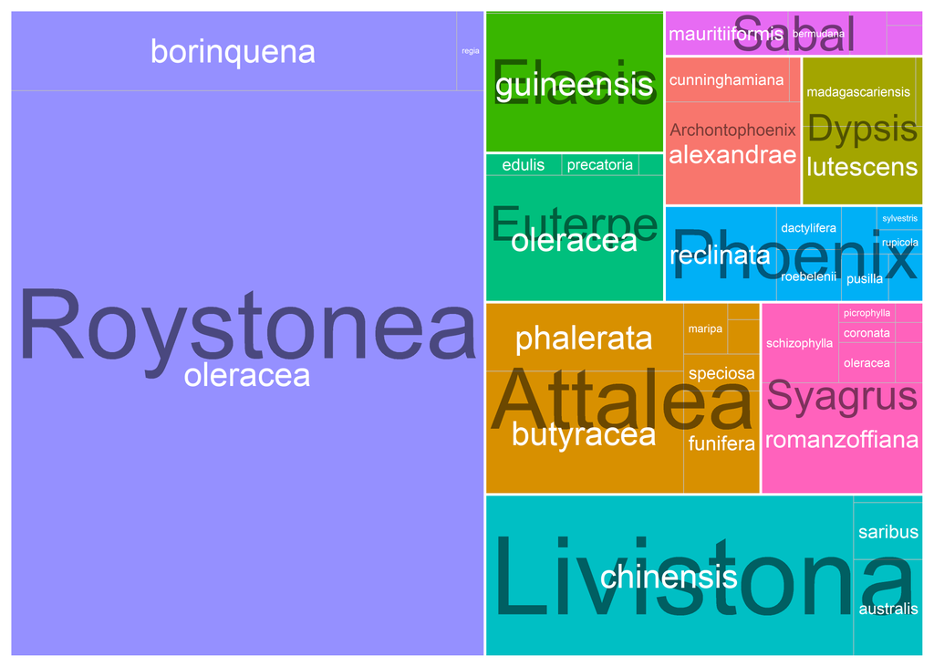

```r
# Top 10 gêneros mais abundantes
top10_generos <- palmeira %>%
  count(genus, sort = TRUE) %>%
  slice_head(n = 10) %>%
  pull(genus)

# Dados para o treemap
tree_palmeira <- palmeira %>%
  filter(genus %in% top10_generos, !is.na(genus),!is.na(species)) %>%
  group_by(genus, species) %>%
  summarise(freq = n()) %>%
  ungroup()

# Treemap
ggplot(tree_palmeira,
       aes(area = freq, fill = genus, label = species, subgroup = genus)) +
  geom_treemap() +
  geom_treemap_subgroup_border(color = "white", size = 2) +
  geom_treemap_subgroup_text(place = "centre",grow = TRUE,alpha = 0.5,color = "black") +
  geom_treemap_text(colour = "white", place = "centre", reflow = TRUE) +
  theme(legend.position = "none")
```

### Os dois gêneros mais abundantes da família representam ela em termos de altura e DAP?

```r
# Criar os grupos
palmeira_anova <- palmeira %>%
  mutate( grupo = case_when(genus == "Roystonea" ~ "Roystonea",genus == "Livistona" ~ "Livistona",
      TRUE ~ "Outros"))
```

```r
# ANOVA para altura. Rta: sugere que os dois gêneros mais abundantes não representam perfeitamente a estrutura vertical geral das palmeiras do arboreto, já que a altura varia fortemente entre os grupos.
anova_altura <- aov(altura ~ grupo, data = palmeira_anova)

summary(anova_altura)
```

```
##               Df Sum Sq Mean Sq F value Pr(>F)
## grupo          2  44624   22312   458.5 <2e-16 ***
## Residuals   1354  65896      49
## ---
## Signif. codes:  0 '***' 0.001 '**' 0.01 '*' 0.05 '.' 0.1 ' ' 1
```

```r
shapiro.test(anova_altura$residuals)
```

```
##
##  Shapiro-Wilk normality test
##
## data:  anova_altura$residuals
## W = 0.99534, p-value = 0.0003348
```

```r
TukeyHSD(anova_altura)
```

```
##   Tukey multiple comparisons of means
##     95% family-wise confidence level
##
## Fit: aov(formula = altura ~ grupo, data = palmeira_anova)
##
## $grupo
##                          diff       lwr        upr     p adj
## Outros-Livistona    -1.226937 -2.721705  0.2678317 0.1317829
## Roystonea-Livistona 10.684204  9.157379 12.2110293 0.0000000
## Roystonea-Outros    11.911141 10.964872 12.8574096 0.0000000
```

```r
# ANOVA para DAP. Rta: os dois gêneros mais abundantes não representam adequadamente a estrutura diamétrica geral da família.

anova_dap <- aov(dap ~ grupo, data = palmeira_anova)

summary(anova_dap)
```

```
##               Df Sum Sq Mean Sq F value Pr(>F)
## grupo          2 331025  165513   935.2 <2e-16 ***
## Residuals   1354 239624     177
## ---
## Signif. codes:  0 '***' 0.001 '**' 0.01 '*' 0.05 '.' 0.1 ' ' 1
```

```r
TukeyHSD(anova_dap)
```

```
##   Tukey multiple comparisons of means
##     95% family-wise confidence level
##
## Fit: aov(formula = dap ~ grupo, data = palmeira_anova)
##
## $grupo
##                          diff       lwr       upr     p adj
## Outros-Livistona     4.322433  1.472005  7.172861 0.0011251
## Roystonea-Livistona 35.350801 32.439243 38.262359 0.0000000
## Roystonea-Outros    31.028369 29.223895 32.832842 0.0000000
```

### 🔴 Sugestão do professor

Como vocês verificaram que a ANOVA para altura não atendeu aos pressupostos, seus resultados não deveriam ter sido considerados, tampouco deveria ter sido realizado o teste de médias. Para o DAP, os pressupostos não foram avaliados. Vocês deveriam ter tentado transformar as variáveis ou realizar testes não paramétricos. Seguem as correções:

```r
library(bestNormalize)
```

```r
# Verificando melhor transformação
bestNormalize(palmeira_anova$altura)
```

```
## Best Normalizing transformation with 1357 Observations
##  Estimated Normality Statistics (Pearson P / df, lower => more normal):
##  - arcsinh(x): 2.3641
##  - Box-Cox: 1.239
##  - Center+scale: 2.3233
##  - Double Reversed Log_b(x+a): 5.1446
##  - Exp(x): 141.2327
##  - Log_b(x+a): 2.3903
##  - orderNorm (ORQ): 1.1921
##  - sqrt(x + a): 1.2397
##  - Yeo-Johnson: 1.2533
## Estimation method: Out-of-sample via CV with 10 folds and 5 repeats
##
## Based off these, bestNormalize chose:
## orderNorm Transformation with 1357 nonmissing obs and ties
##  - 1001 unique values
##  - Original quantiles:
##    0%   25%   50%   75%  100%
##  1.30  9.65 14.40 22.20 42.31
```

```r
# Aplicando ordenação quantílica
quant_alt <- orderNorm(palmeira_anova$altura)
```

```r
# Refazendo a ANOVA
ano_palm <- aov(quant_alt$x.t ~ palmeira_anova$grupo)
```

```r
# Testando normalidade dos resíduos
shapiro.test(ano_palm$residuals)
```

```
##
##  Shapiro-Wilk normality test
##
## data:  ano_palm$residuals
## W = 0.98304, p-value = 1.595e-11
```

```r
# Testando homogeneidade das variâncias
bartlett.test(quant_alt$x.t, palmeira_anova$grupo)
```

```
##
##  Bartlett test of homogeneity of variances
##
## data:  quant_alt$x.t and palmeira_anova$grupo
## Bartlett's K-squared = 30.388, df = 2, p-value = 2.52e-07
```

```r
# Realizando o teste de Kruskal-Wallis
k_palm <- kruskal.test(altura ~ grupo, data = palmeira_anova)

# Visualizando
k_palm
```

```
##
##  Kruskal-Wallis rank sum test
##
## data:  altura by grupo
## Kruskal-Wallis chi-squared = 506.65, df = 2, p-value < 2.2e-16
```

```r
library(rstatix)
```

```r
# Teste de Dunn para comparações múltiplas
palmeira_anova %>%
  dunn_test(altura ~ grupo, p.adjust.method = "holm")
```

```
## # A tibble: 3 × 9
##   .y.    group1    group2    n1    n2 statistic         p     p.adj p.adj.signif
## * <chr>  <chr>     <chr>  <int> <int>     <dbl>     <dbl>     <dbl> <chr>
## 1 altura Livistona Outros   146   671     -2.19 2.85e-  2 2.85e-  2 *
## 2 altura Livistona Royst…   146   540     11.6  6.70e- 31 1.34e- 30 ****
## 3 altura Outros    Royst…   671   540     22.1  2.57e-108 7.71e-108 ****
```

```r
# Transformando grupo em fator
palmeira_anova <- palmeira_anova %>%
  mutate(grupo = factor(grupo, levels = c("Roystonea", "Livistona", "Outros")))

# Resultado do teste
letras_mediana <- palmeira_anova %>%
  group_by(grupo) %>%
  summarise(mediana = median(altura, na.rm = TRUE), .groups = "drop") %>%
  arrange(desc(mediana)) %>%
  mutate(letra = letters[1:n()], label = paste0(sprintf("%.1f", mediana), " ", letra))
```

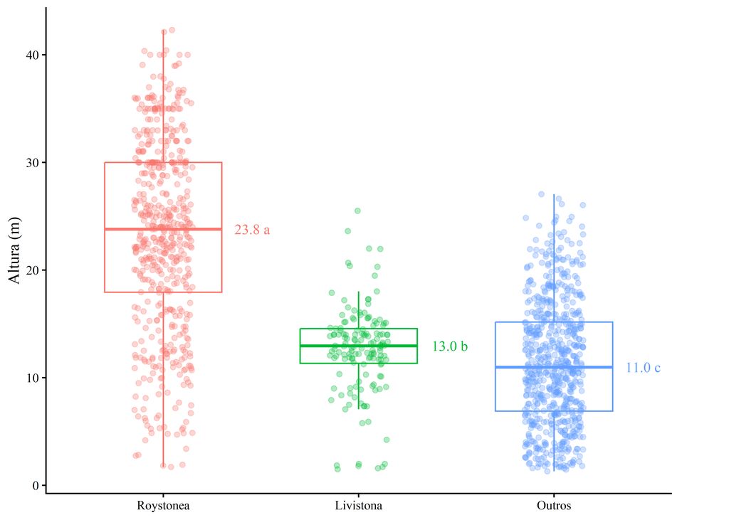

```r
# Visualização
ggplot(palmeira_anova, aes(x = grupo, y = altura, color = grupo)) +
  geom_boxplot(outlier.shape = NA, width = 0.6) +
  geom_jitter(width = 0.15, alpha = 0.3, size = 1.5) +
  geom_text(data = letras_mediana, aes(x = grupo, y = mediana, label = label, color = grupo), inherit.aes = FALSE, hjust = -2, size = 3.5, family = "serif") +
  coord_cartesian(clip = "off") +
  labs(x = NULL, y = "Altura (m)") +
  theme_classic() +
  theme(legend.position = "none",
    text = element_text(family = "serif"),
    plot.margin = margin(5.5, 40, 5.5, 5.5))
```

```r
# Verificando melhor transformação
bestNormalize(palmeira_anova$dap)
```

```
## Best Normalizing transformation with 1357 Observations
##  Estimated Normality Statistics (Pearson P / df, lower => more normal):
##  - arcsinh(x): 4.5087
##  - Box-Cox: 3.9939
##  - Center+scale: 4.1707
##  - Double Reversed Log_b(x+a): 5.5753
##  - Exp(x): 146.4734
##  - Log_b(x+a): 4.5212
##  - orderNorm (ORQ): 1.0471
##  - sqrt(x + a): 4.019
##  - Yeo-Johnson: 4.0024
## Estimation method: Out-of-sample via CV with 10 folds and 5 repeats
##
## Based off these, bestNormalize chose:
## orderNorm Transformation with 1357 nonmissing obs and ties
##  - 875 unique values
##  - Original quantiles:
##    0%   25%   50%   75%  100%
## 10.19 25.91 40.23 63.66 95.17
```

```r
# Aplicando ordenação quantílica
quant_dap <- orderNorm(palmeira_anova$dap)
```

```r
# Refazendo a ANOVA
ano_palm_d <- aov(quant_dap$x.t ~ palmeira_anova$grupo)
```

```r
# Testando normalidade dos resíduos
shapiro.test(ano_palm_d$residuals)
```

```
##
##  Shapiro-Wilk normality test
##
## data:  ano_palm_d$residuals
## W = 0.97332, p-value = 3.811e-15
```

```r
# Testando homogeneidade das variâncias
bartlett.test(quant_dap$x.t, palmeira_anova$grupo)
```

```
##
##  Bartlett test of homogeneity of variances
##
## data:  quant_dap$x.t and palmeira_anova$grupo
## Bartlett's K-squared = 184.98, df = 2, p-value < 2.2e-16
```

```r
# Realizando o teste de Kruskal-Wallis
k_palm_d <- kruskal.test(dap ~ grupo, data = palmeira_anova)

# Visualizando
k_palm_d
```

```
##
##  Kruskal-Wallis rank sum test
##
## data:  dap by grupo
## Kruskal-Wallis chi-squared = 750.57, df = 2, p-value < 2.2e-16
```

```r
# Teste de Dunn para comparações múltiplas
palmeira_anova %>%
  dunn_test(dap ~ grupo, p.adjust.method = "holm")
```

```
## # A tibble: 3 × 9
##   .y.   group1    group2     n1    n2 statistic         p     p.adj p.adj.signif
## * <chr> <chr>     <chr>   <int> <int>     <dbl>     <dbl>     <dbl> <chr>
## 1 dap   Roystonea Livist…   540   146    -17.9  6.83e- 72 1.37e- 71 ****
## 2 dap   Roystonea Outros    540   671    -25.6  1.13e-144 3.38e-144 ****
## 3 dap   Livistona Outros    146   671      2.10 3.56e-  2 3.56e-  2 *
```

```r
# Resultado do teste
letras_mediana_dap <- palmeira_anova %>%
  group_by(grupo) %>%
  summarise(mediana = median(dap, na.rm = TRUE), .groups = "drop") %>%
  arrange(desc(mediana)) %>%
  mutate(letra = letters[1:n()], label = paste0(sprintf("%.1f", mediana), " ", letra))
```

[figure not shown]

```r
# Visualização
ggplot(palmeira_anova, aes(x = grupo, y = dap, color = grupo)) +
  geom_boxplot(outlier.shape = NA, width = 0.6) +
  geom_jitter(width = 0.15, alpha = 0.3, size = 1.5) +
  geom_text(data = letras_mediana_dap, aes(x = grupo, y = mediana, label = label, color = grupo), inherit.aes = FALSE, hjust = -2, size = 3.5, family = "serif") +
  coord_cartesian(clip = "off") +
  labs(x = NULL, y = "Altura (m)") +
  theme_classic() +
  theme(legend.position = "none",
    text = element_text(family = "serif"),
    plot.margin = margin(5.5, 40, 5.5, 5.5))
```

### Avaliem a altura dominante de Roystonea nos canteiros em que ela ocorre.

#### Filtrando por gênero Roystonea

```r
# Filtrando Roystonea
roystonea <- palmeira %>%
  filter(genus == "Roystonea")
```

#### Avaliando o gênero por altura dominante

```r
#Calcular a altura dominante no genero
altura_dom_roy <- roystonea %>%
  group_by(sec_cant) %>%
  slice_max(altura, n = 1) %>%
  summarise(
    altura_dominante = mean(altura),
    n_ind = first(n())
  )
```

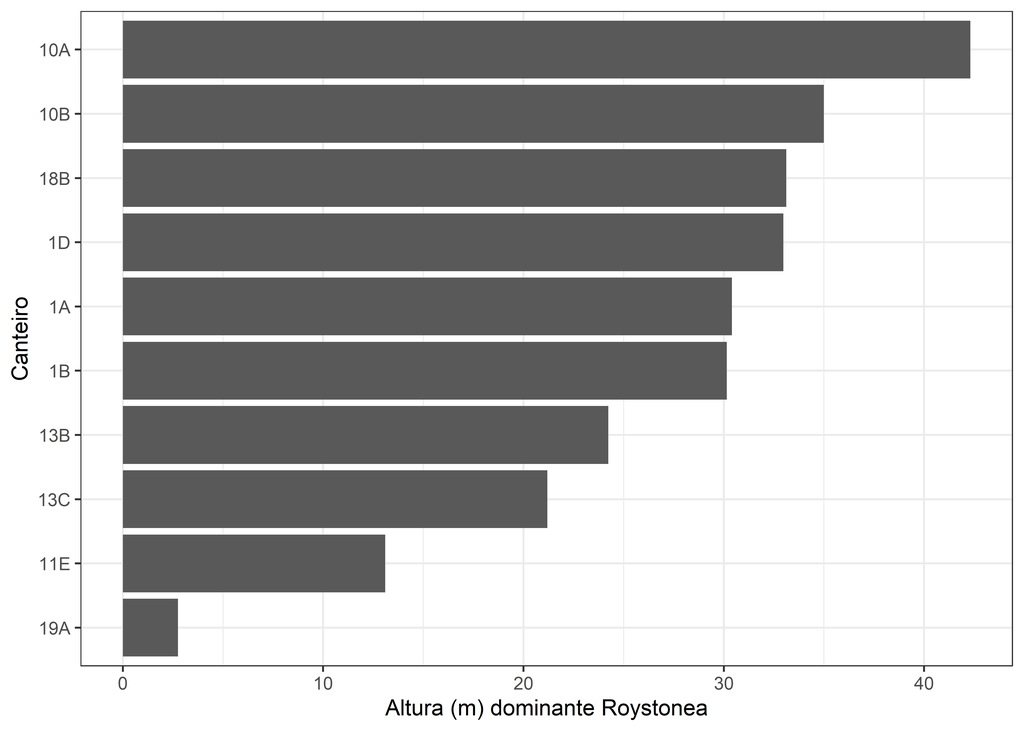

```r
#Visualização
# para as 10 roystonea mais altas
roystonea2 <- roystonea %>%
  group_by(sec_cant) %>%
  slice_max(altura, n = 1) %>%
  summarise(
    altura_dominante = mean(altura),
    n_ind = first(n())) %>%
  slice_head(n = 10)

#plot de roystonea altura dominantes por canteiro
ggplot(roystonea2,
       aes(x = reorder(sec_cant, altura_dominante),
           y = altura_dominante)) +
  geom_col() +
  coord_flip() +
  theme_bw() +
  labs(
    x = "Canteiro",
    y = "Altura (m) dominante Roystonea"
  )
```

### 🔴 Sugestão do professor

Minha sugestão seria filtrar os canteiros com três ou mais indivíduos de *Roystonea*, pois não faria sentido estimar a altura dominante da espécie em canteiros com menor número de indivíduos.

```r
# Seleção canteiros com 3 ou mais indivíduos de Roystonea
canteiros_roy <- palmeira %>%
  filter(genus == "Roystonea") %>%
  group_by(sec_cant) %>%
  filter(n() >= 3) %>%
  ungroup()

unique(canteiros_roy$sec_cant)
```

```
##  [1] "1A"  "1B"  "2A"  "2B"  "3A"  "3B"  "3D"  "3F"  "4A"  "4B"  "4G"  "5C"
## [13] "5D"  "6A"  "6D"  "7D"  "7F"  "8A"  "8D"  "9C"  "10A" "13B" "13C" "20A"
## [25] "20B" "26A" "26B" "30F" "30G" "31A" "31B" "32A" "32C" "1F"  "26F"
```

```r
# Calcular a altura dominante no genero
altura_dom_roy <- canteiros_roy %>%
  group_by(sec_cant) %>%
  slice_max(altura, n = 1, with_ties = FALSE)
```

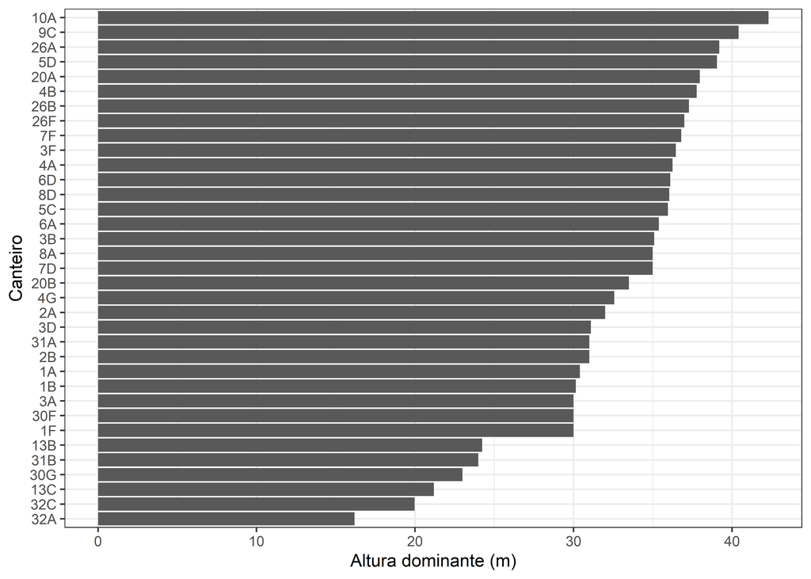

```r
# Gráfico da altura dominante de Roystonea
ggplot(altura_dom_roy, aes(x = reorder(sec_cant, altura), y = altura)) +
  geom_col() +
  coord_flip() +
  theme_bw() +
  labs(x = "Canteiro", y = "Altura dominante (m)")
```